# OLWTEF

JJayes

05/09/2020

# How do we thrive?

## Share of population living in extreme poverty by region

Our world in data figures from Bourgion and Morrison, World Bank

## Share of population living in absolute poverty

Share of population living in absolute poverty: Colours

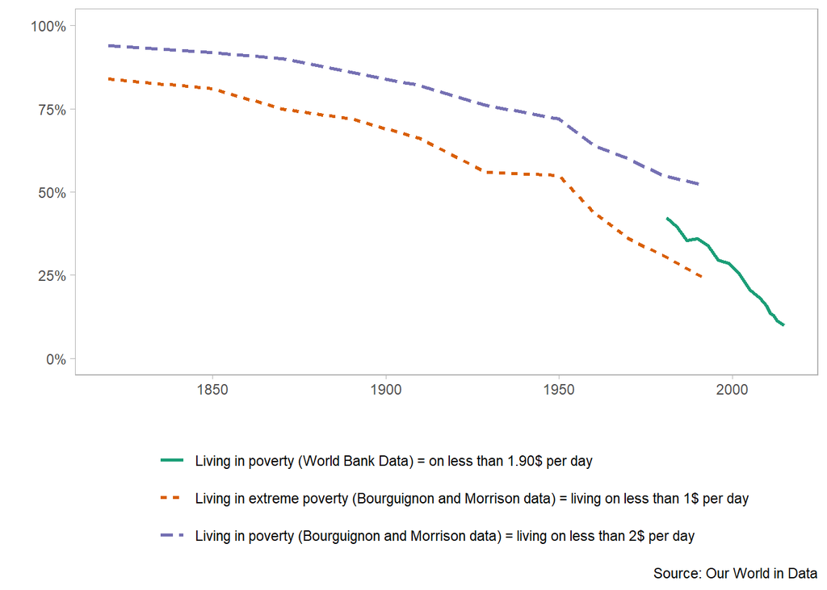

Share of population living in absolute poverty: Thick, dotted grey lines

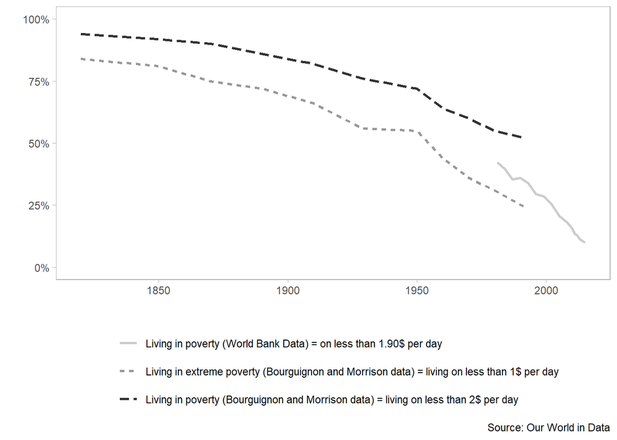

Share of population living in absolute poverty: Thin dotted lines

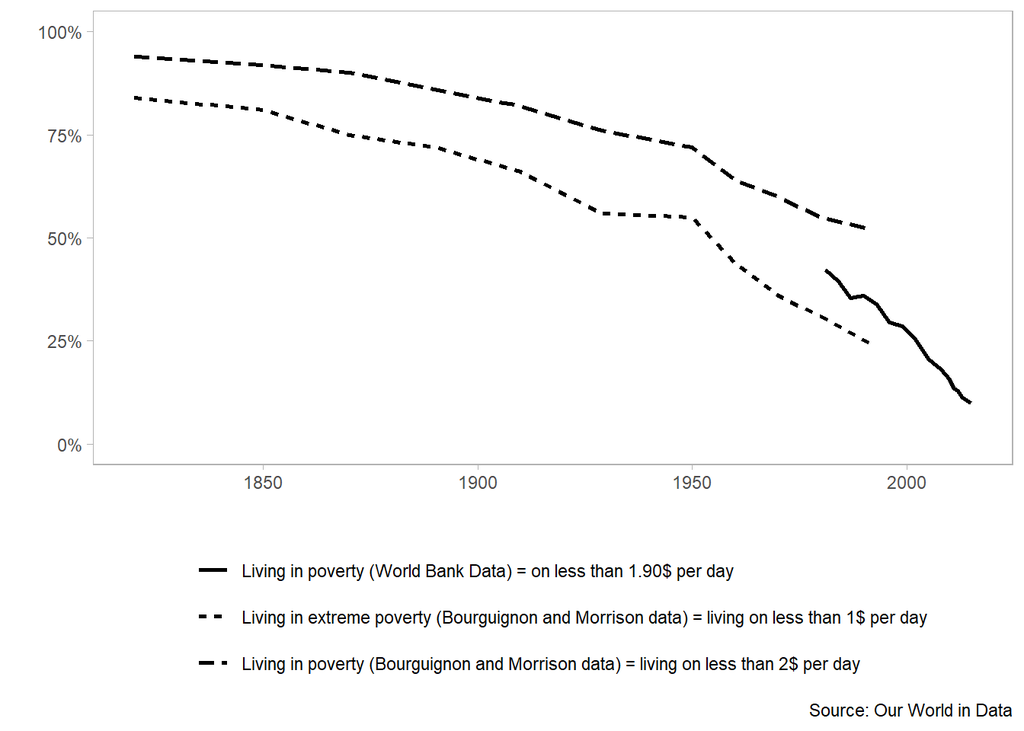

Share of population living in absolute poverty: shaded lines

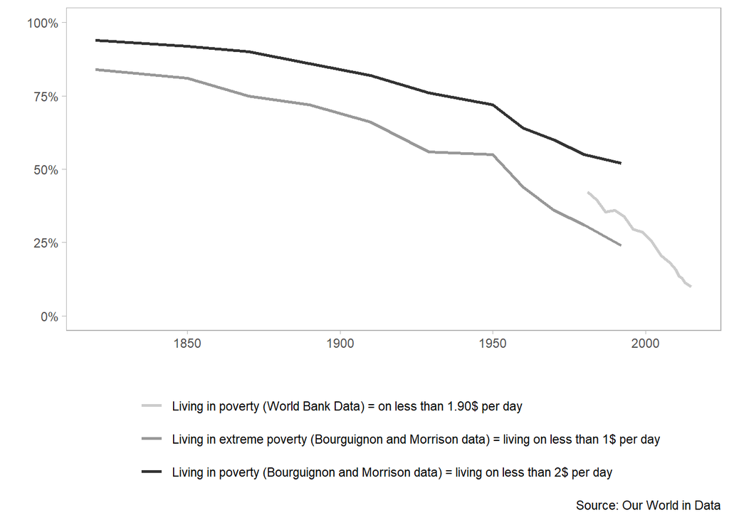

### Share of population living in extreme poverty by world region

Share of population living in extreme poverty by region: Colours

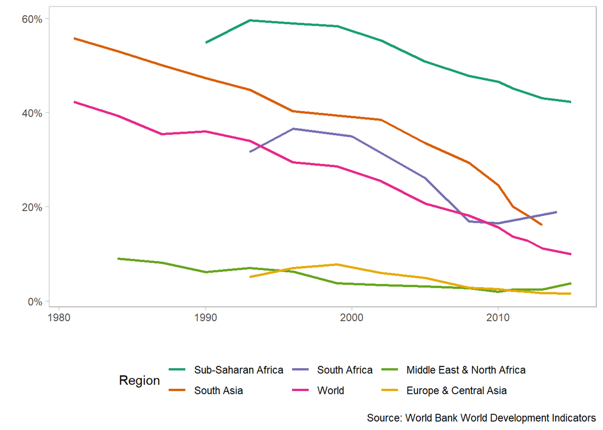

Share of population living in extreme poverty by region: Thin dotted lines and legend

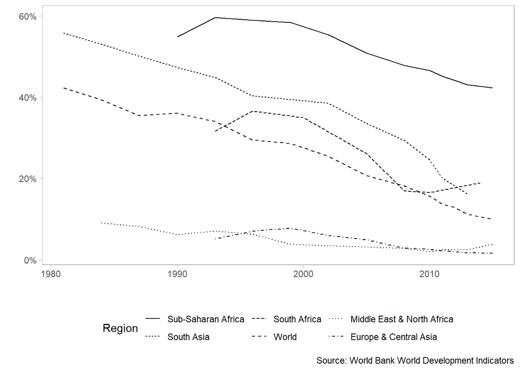

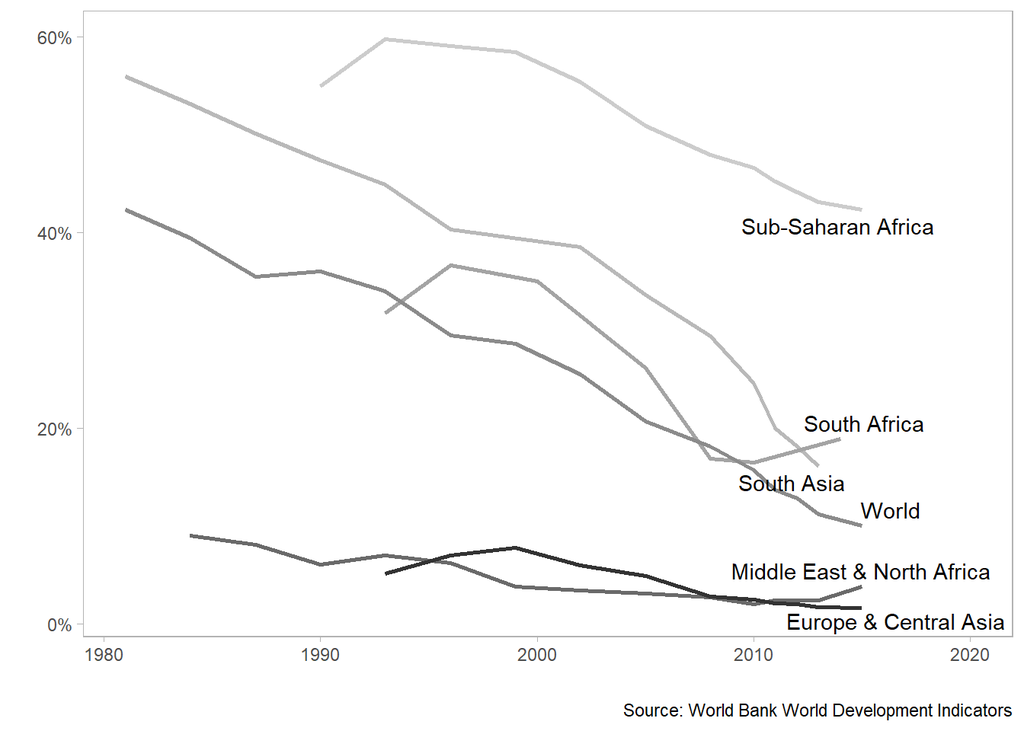

Share of population living in extreme poverty by region: Shaded thick dotted line and a legend

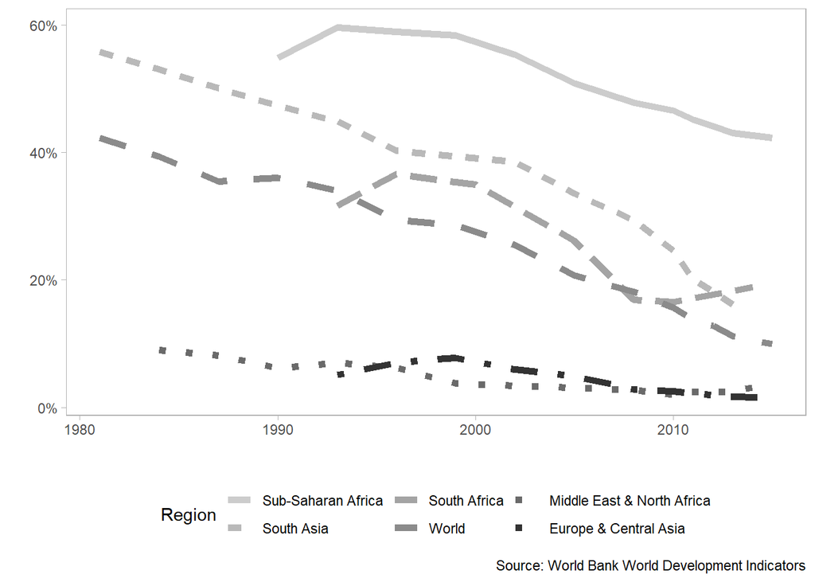

Share of population living in extreme poverty by region: Thinner dotted line and a legend

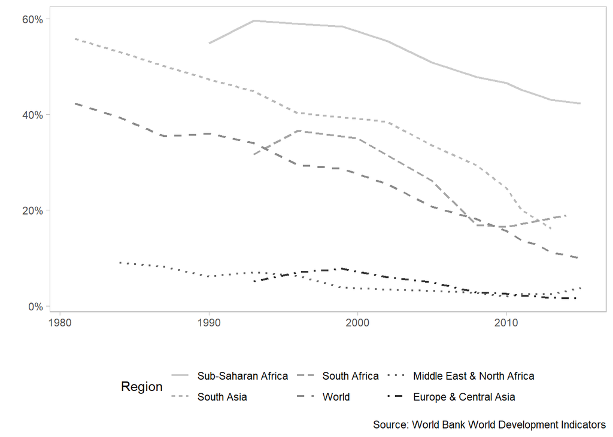

..

All of the following plots can be done with any selection of these styles, as you like the look most.

..

# Chapter 1: Who are the architects of Wakanda? African economic historians and the stories we tell

(Choice of countries here can be changed)

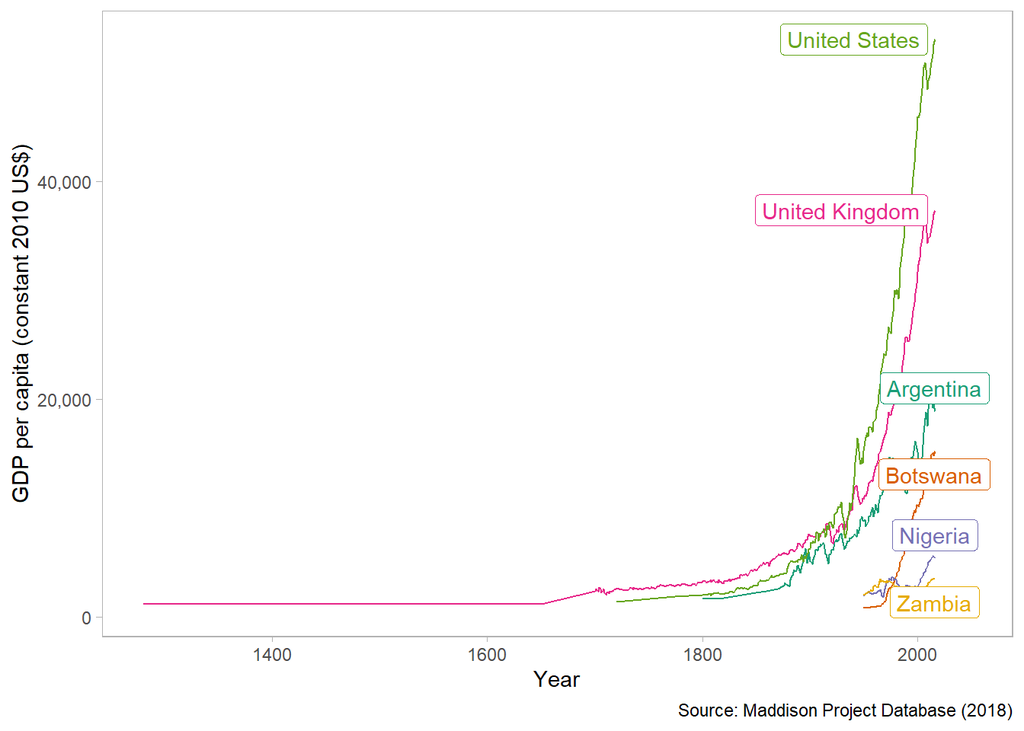

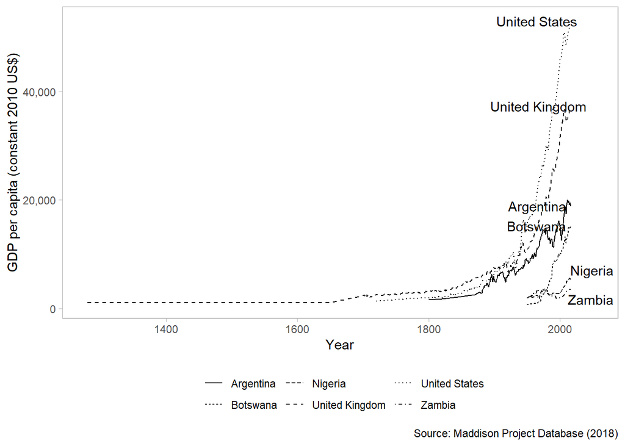

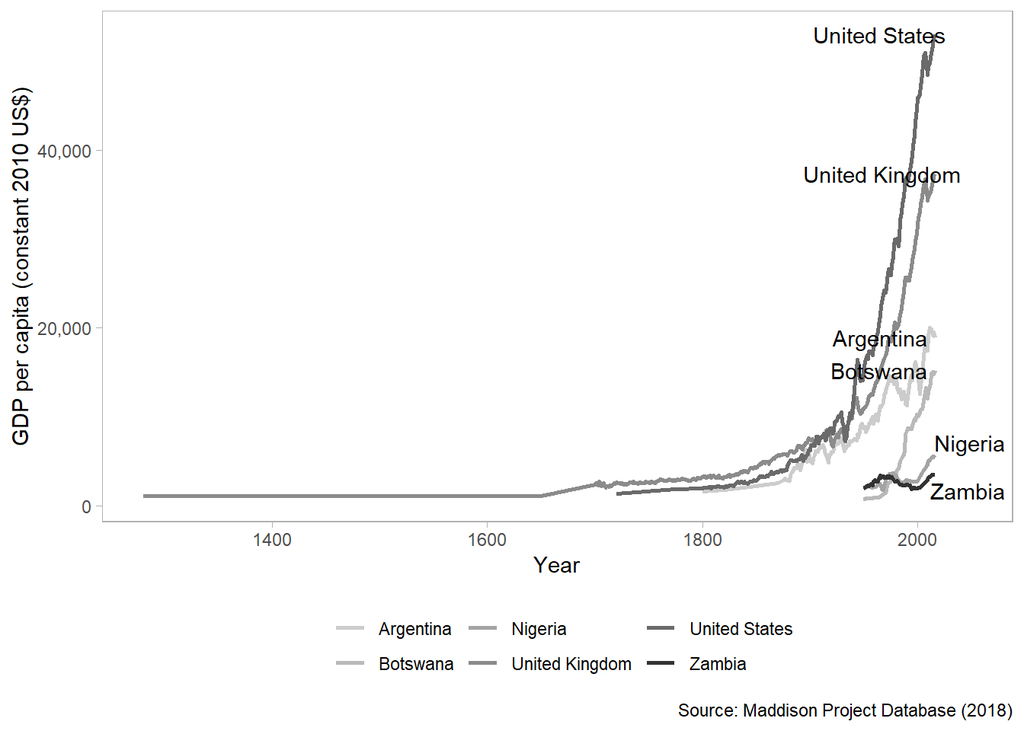

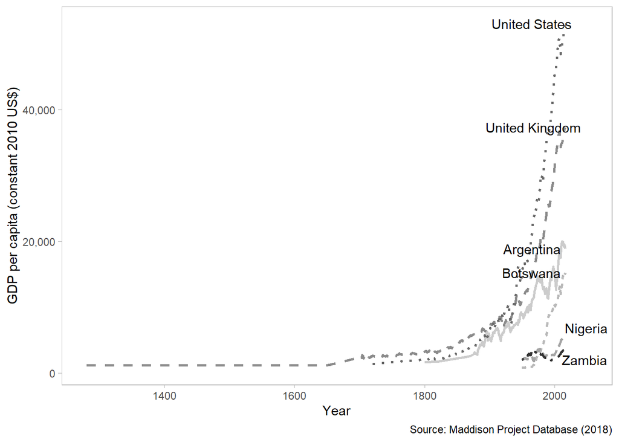

#Chapter 2: What happened at Blombos in 70000 BCE? The Out-of-Africa hypothesis and the peopling of the world

### Ashraf and Galor

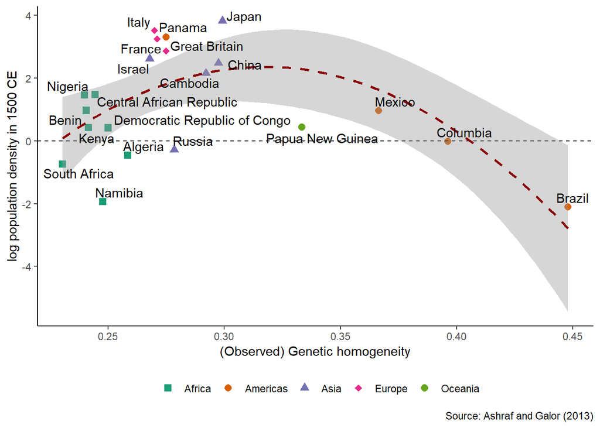

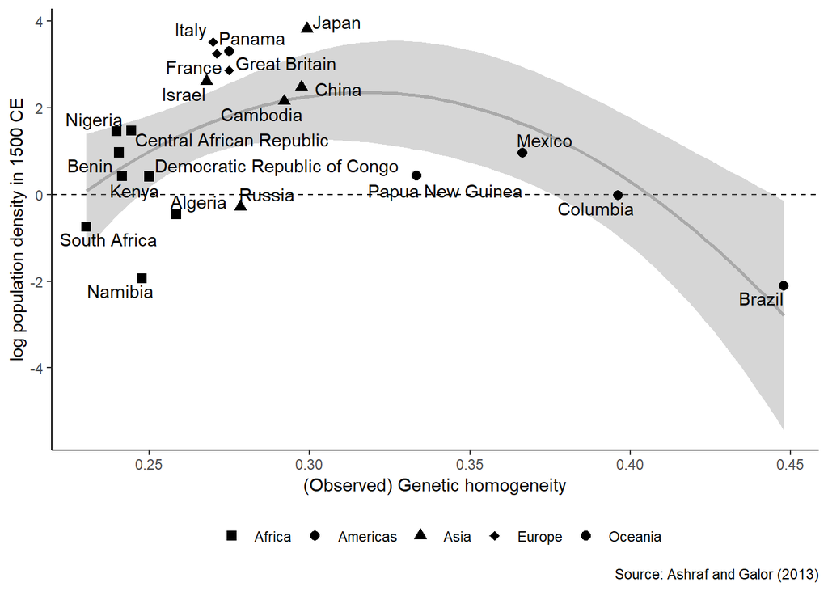

# Chapter 3: Why are the Danes so individualistic? The Neolithic Revolution and the rise of civilizations

Olsson and Paik figure attached to email.

# Chapter 4: Why does isiXhosa have clicks? The Bantu migration

Map attached to email.

# Chapter 8: Who was the richest man to ever live? The spread of Islam in Africa and the Crusades

## Timeline of Jerusalem

Timeline of Jerusalem: Dotted lines - labels on y-axis

(Can change source here if you would prefer not to cite Wikipedia)

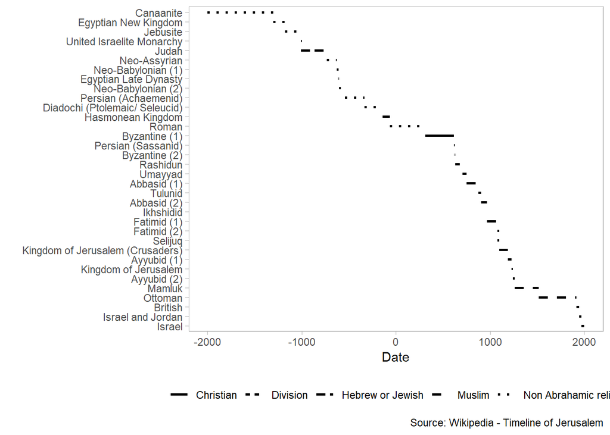

Timeline of Jerusalem: Shades of grey - labels on y-axis

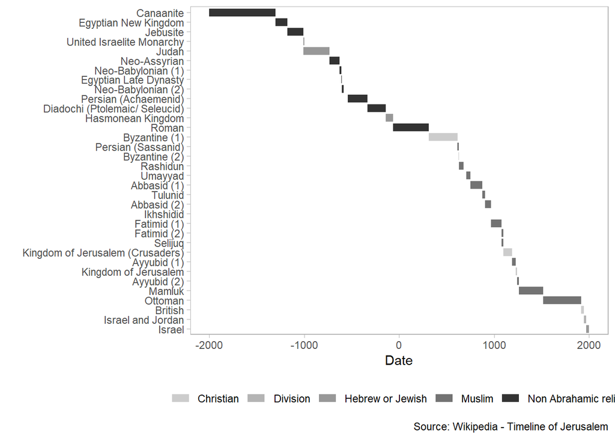

Timeline of Jerusalem: Alternate dotted lines - labels beside lines

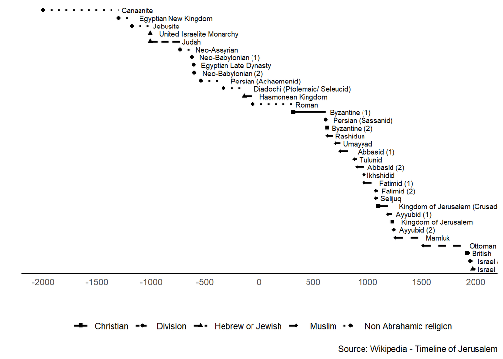

Timeline of Jerusalem: Alternate shades of grey - labels beside lines. Personally I like this one the most.

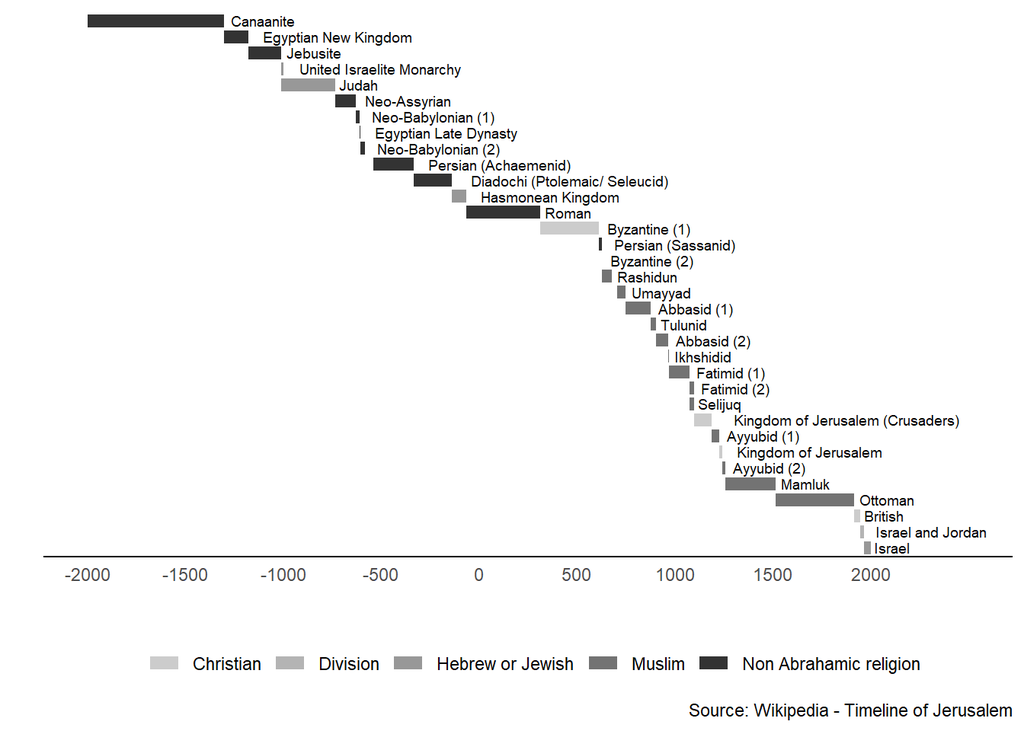

Timeline of Jerusalem: showing crusades with vertical lines - Johan, please correct the dates here?

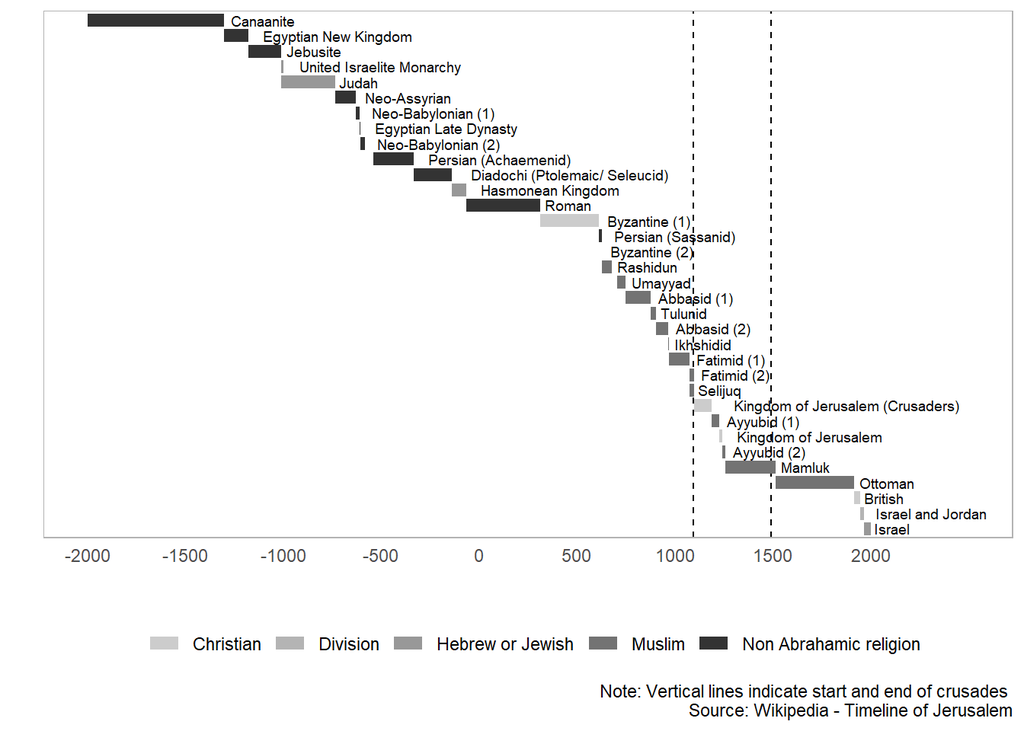

Timeline of Jerusalem: Colours and showing crusades with vertical lines

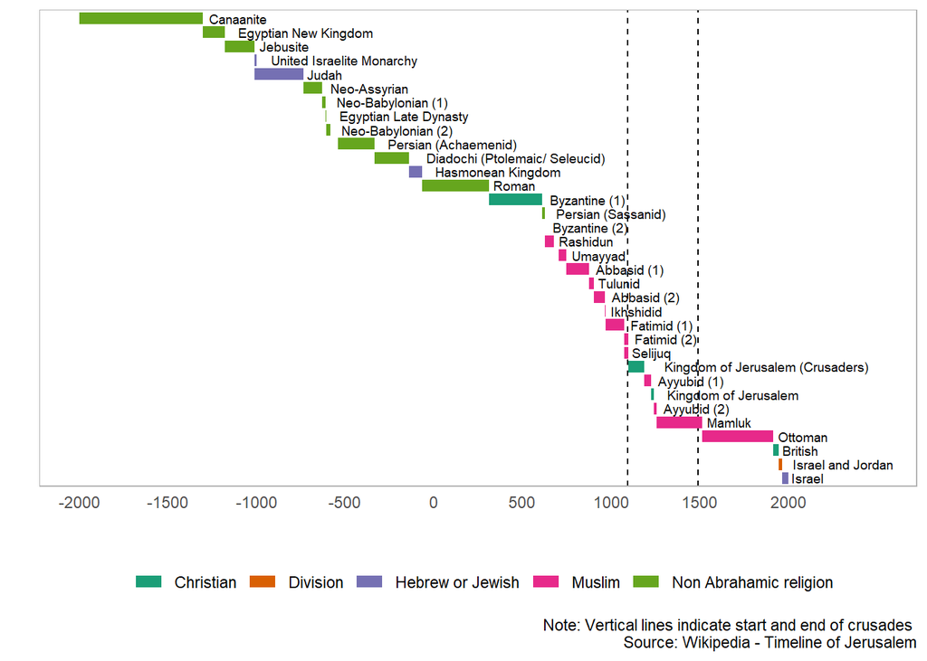

# Chapter 11: Who visited Goree island on 27 June 2013? The Atlantic slave trade and Africa’s long-run development

Attached to email.

# Chapter 16: Why was the Spinning Jenny not invented in India? Science, technology and the Industrial Revolution

GDP per capita in England. Adjusted for inflation and measured in British Pounds in 2013 prices.

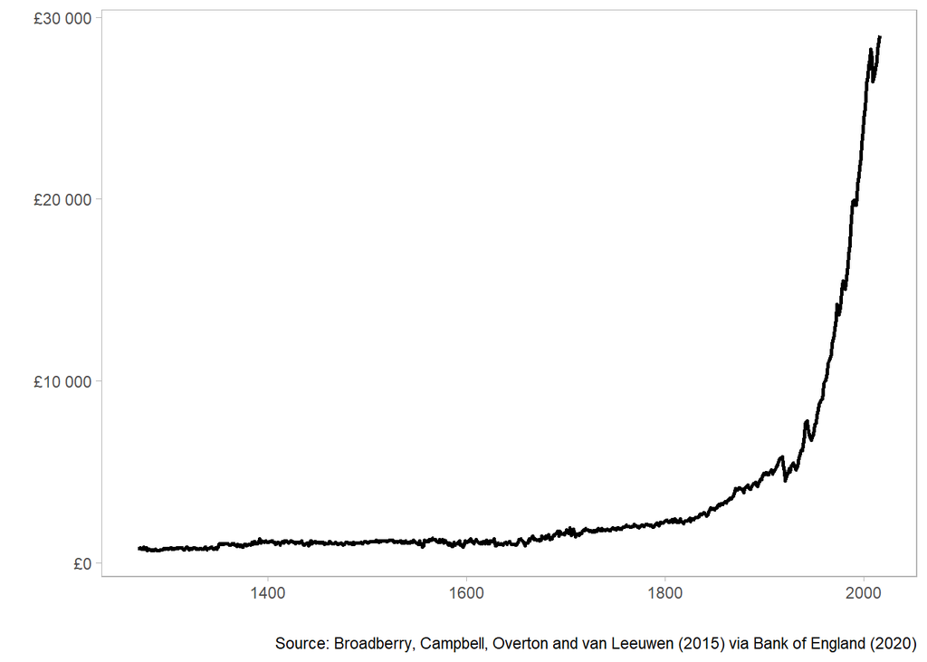

# Chapter 17: Why did railways hurt Basotho farmers? South Africa’s mineral revolution

Johan, please advise on a title and source here?

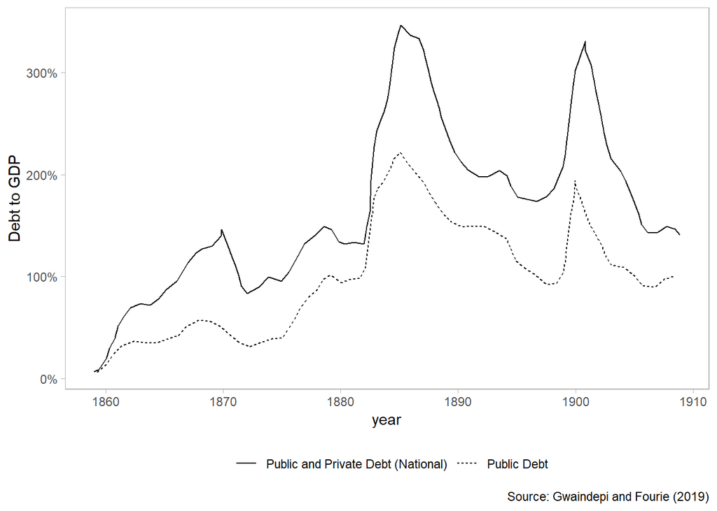

# Chapter 21:What was new about the New Deal? The Great Depression and the New Deal

From caption: Difference from 1929 in Real GDP, Federal Government Outlays, Revenues, Surplus/deficit as a percentage of 1929 Real GDP.

Source?? y-axis label??

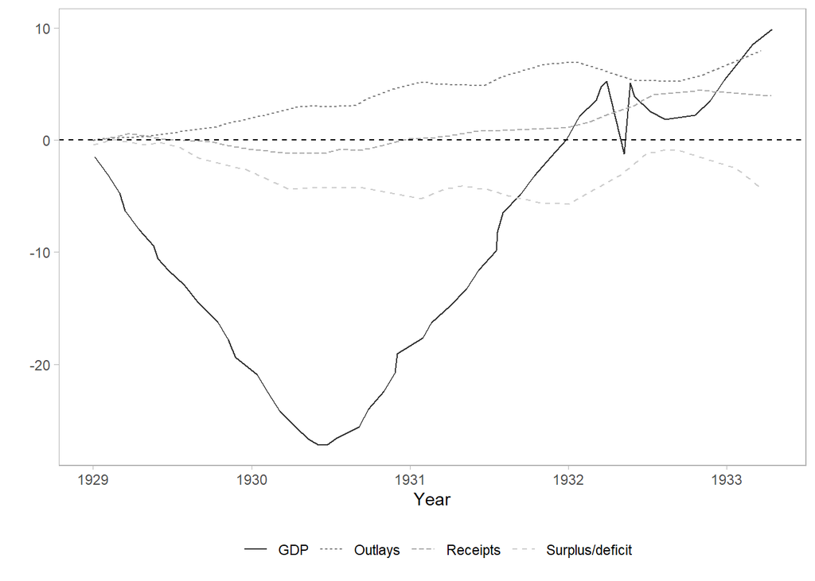

# Chapter 22: How could a movie embarrass Stalin? Russia and the turn to communism

## Graph comparing USA and USSR growth

Graph comparing USA and USSR growth: colours

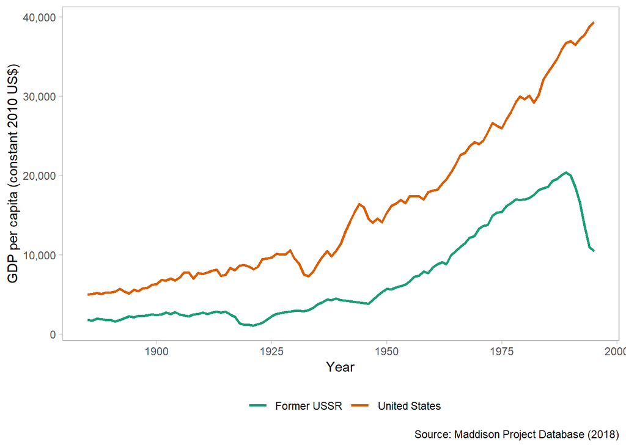

Graph comparing USA and USSR growth: dotted line and in pane labels

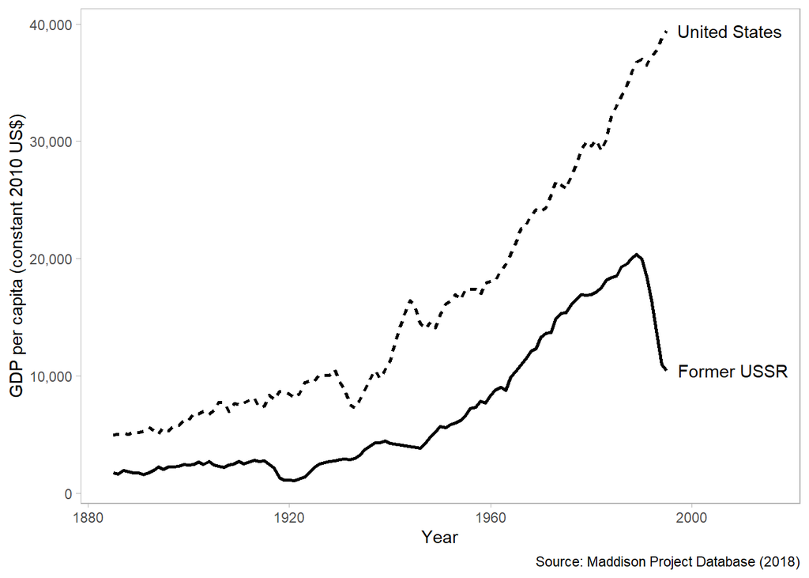

Graph comparing USA and USSR growth: Grey lines

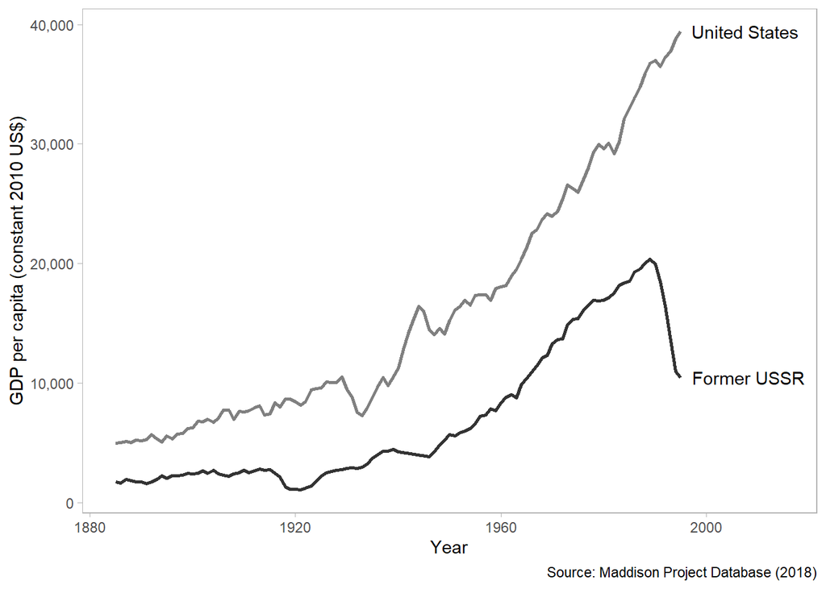

Graph comparing USA and USSR growth: Dotted grey lines and legend

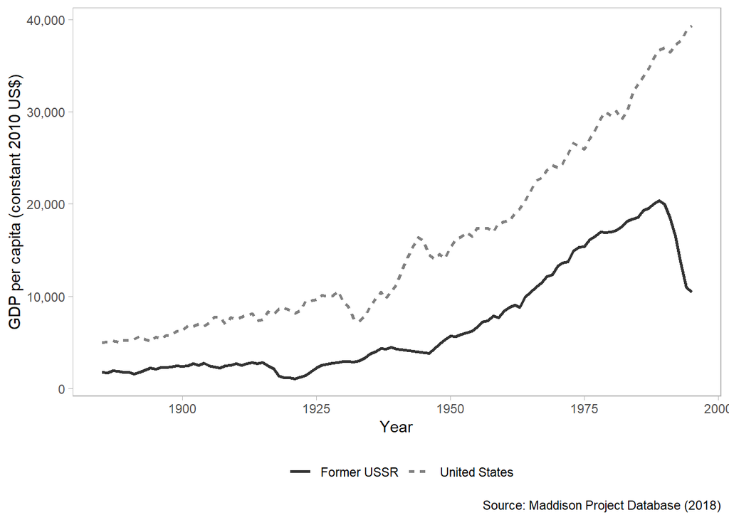

# Chapter 23: What was the Great Leap Forward? Mao Zedong, famine and the Cultural Revolution

The national inventory of draft animals and quantity of cowhides sold nationwide

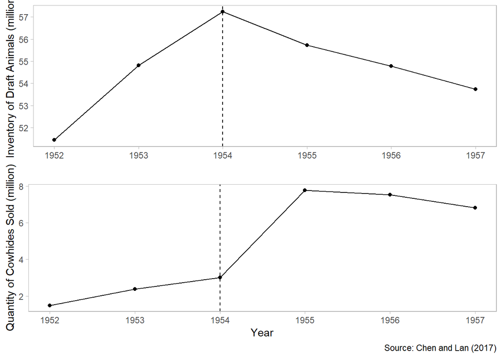

# Chapter 24: Why should we cry for Argentina? A country reverses

GDP per capita in 1900 vs GDP per capita in 2000

Argentina highlighted on evolution of GDP: Greyscale

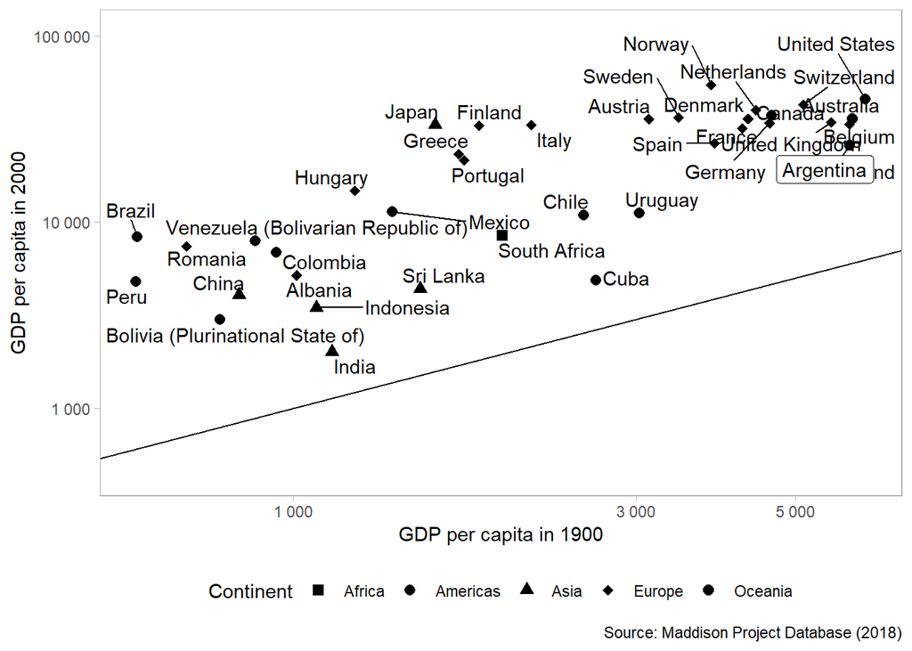

Argentina highlighted on evolution of GDP: Colours

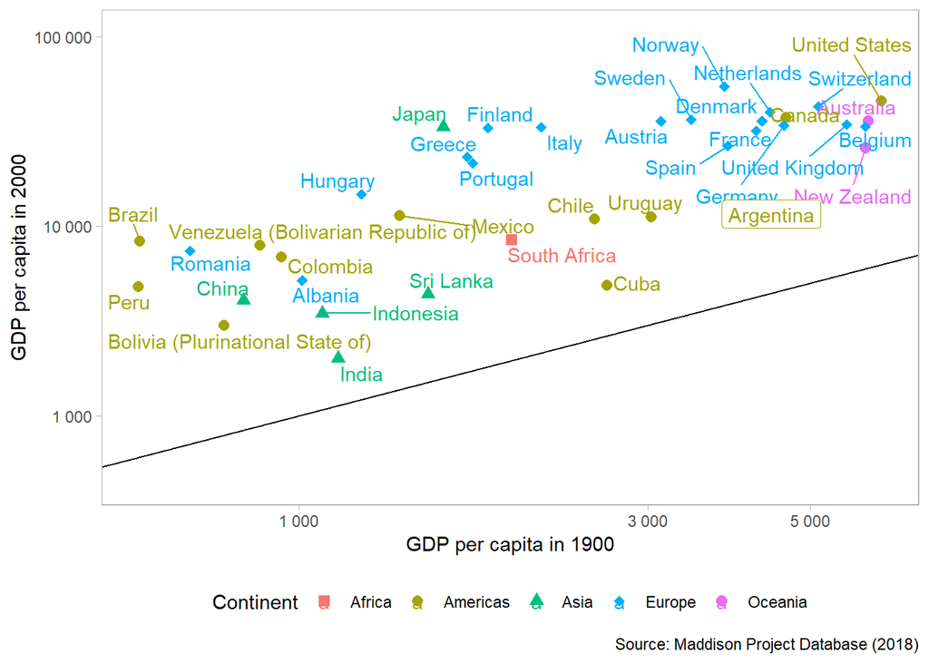